# Confidence Interval for 1 mean

Mike Hitchman

10/20/2021

### The Scene

This page helps with finding a level $C$ confidence interval for a population mean $\mu$.

We assume the population standard deviation $\sigma$ is unknown so we use a t-distribution to determine the confidence interval.

If we draw a simple random sample of size $n$, a confidence interval for $\mu$ has the form

$$\bar{x} \pm t^* \cdot \frac{s}{\sqrt{n}}$$
where

- $\bar{x}$ is the sample mean
- $s$ is the sample standard deviation
- $t^*$ is the value in the t-distribution with df = $n-1$ such that $P(-t^* < T_{df} < t^*)=C$

### The Example

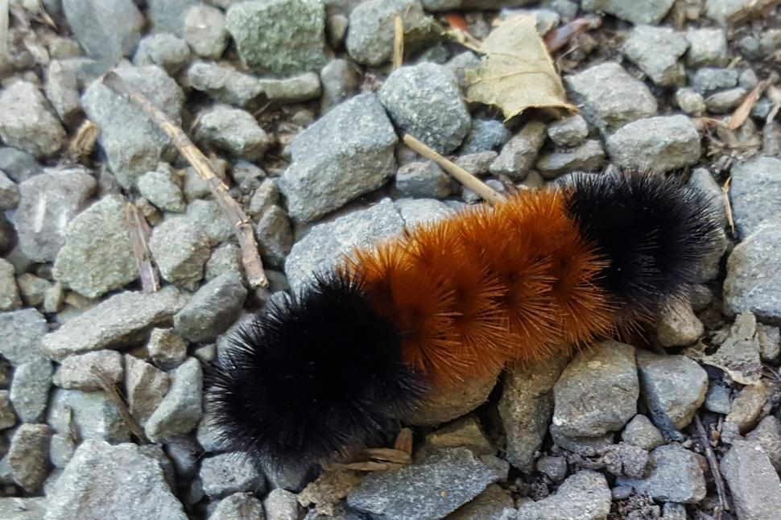

The majestic woolly bear caterpillar

The data vector `wb` below gives the length measurements (in millimeters) of an independent sample of woolly bear caterpillars.

```r
wb = c(52.0, 48.9, 47.3, 47.3, 48.6, 48.8, 42.8, 44.3, 46.7, 46.4, 47.5, 51.4, 49.0, 47.7, 48.5, 48.5, 45.8, 49.3, 48.1, 46.5)
```

Based on this sample, determine a 95% confidence interval for $\mu$, the population mean length of woolly bear caterpillars.

We can follow the Prepare-Check-Calculate-Conclude procedure:

**Prepare** for the interval: The sample size $n$, the sample mean $\bar{x}$, and the sample standard deviation $s$:

```r
n = length(wb)
xbar = mean(wb)
s = sd(wb)
```

$n$ = 20; $\bar{x}$ = 47.77; $s$ = 2.1138889

**Check** We can plot the sample data to check for extreme observations.

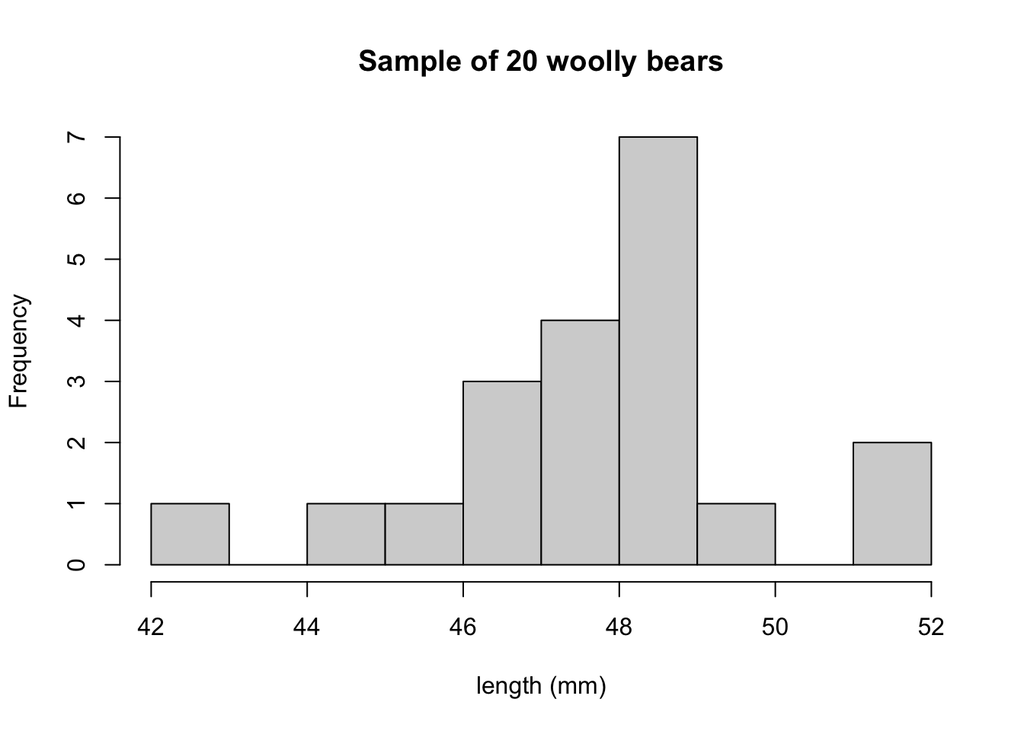

```r
hist(wb,breaks=12,main=paste("Sample of",n,"woolly bears"),xlab="length (mm)")
```

Measurements in nature such as length and weight often follow a normal distribution. These data have no strong skewness or real outliers to suggest otherwise in this case. The sample size is 20, and the t-distribution with 19 df is a reasonable model for the sampling distribution for $\bar{x}$.

**Calculate** the confidence interval.

### The code

We include the entire calculation in one code chunk:

```r
wb = c(52.0, 48.9, 47.3, 47.3, 48.6, 48.8, 42.8, 44.3, 46.7, 46.4, 47.5, 51.4, 49.0, 47.7, 48.5, 48.5, 45.8, 49.3, 48.1, 46.5) # the data
n=length(wb) #sample size
xbar=mean(wb) #sample mean
s = sd(wb) #sample standard deviation
C = .95 # confidence level
df = n-1 #degrees of freedom
SE = s/sqrt(n)
tstar = qt(C + (1-C)/2,df)
MOE = tstar*SE
xbar + c(-MOE,MOE) #Confidence Interval
```

```
## [1] 46.78067 48.75933
```

```r
# We can also ask Rstudio to print a summary:
cat(paste0("sample mean = ",round(xbar,4),"\n","t* = ",round(tstar,3),"\n",
           "MOE = ",round(MOE,4),"\n",
           C*100,"% confidence interval for ", expression(mu),": ",round(xbar - MOE,4), " to ", round(xbar + MOE,4),"."))
```

```
## sample mean = 47.77
## t* = 2.093
## MOE = 0.9893
## 95% confidence interval for mu: 46.7807 to 48.7593.
```

**Conclude.** We are 95% confident that the population mean $\mu$ length of woolly bear caterpillars is between 46.8 and 48.8 millimeters.

### t.test()

The built-in `t.test()` function in R can generate a confidence interval that matches the one we compute using the formula in the text. (It also conducts a test of significance, which we discuss in the test_one_mean page.)

```r
t.test(wb, conf.level = 0.95)
```

```
##
##  One Sample t-test
##
## data:  wb
## t = 101.06, df = 19, p-value < 2.2e-16
## alternative hypothesis: true mean is not equal to 0
## 95 percent confidence interval:
##  46.78067 48.75933
## sample estimates:
## mean of x
##     47.77
```

- `wb` is the name of the data set
- `conf.level` is the confidence level :)